# How to use SynTruth

Dora Schuller

2022-07-11

# I. Create a synthetic dataset

Set parameters.

```r
# This is an example parameter list with one marker block.

params <- list(
  # parameters for marker blocks
  marker_blocksizes = c(10),
  mus_NB = c(0),
  mu_diffs = c(2),
  sds_B = c(0.4),
  sds_NB = c(0.4),
  rhos_B = c(0.8),
  rhos_NB = c(0.8),
  gene_effects = c("AND"),

  # parameters for nonmarker blocks
  mu_nonmarker = 0,
  sds_nonmarker = c(0.4),
  rhos_nonmarker = c(0.8),

  # parameters for gep
  n_pts = 1000,
  n_genes = 100,
  fraction_pts_benefit = 0.5,
  fraction_tx_1 = 0.5,
  fraction_censored = 0,
  noise = list(type = "random", mean = 0, sd = 1),

  # parameters for survival
  surv_distribution = "Weibull",
  surv_d_params = list(shape=1.5),
  scale_NB0 = 10,
  HR_B0_NB0 = 0.7,
  HR_NB1_NB0 = 0.9,
  HR_B1_NB0 = 0.5)

# This is another example parameter list with two marker blocks.

params <- list(
  # parameters for marker blocks
  marker_blocksizes = c(5, 5),
  mus_NB = c(0, 0),
  mu_diffs = c(1, 2),
  sds_B = c(0.4, 0.4),
  sds_NB = c(0.4, 0.4),
  rhos_B = c(0.8, 0.8),
  rhos_NB = c(0.8, 0.8),
  gene_effects = c("AND", "no_pattern"),

  # parameters for nonmarker blocks
  mu_nonmarker = 0,
  sds_nonmarker = c(0.3, 0.6),
  rhos_nonmarker = c(0.8, 0.8),

  # parameters for gep
  n_pts = 1000,
  n_genes = 100,
  fraction_pts_benefit = 0.5,
  fraction_tx_1 = 0.5,
  fraction_censored = 0,
  noise = list(type = "random", mean = 0, sd = 1),

  # parameters for survival
  surv_distribution = "Weibull",
  surv_d_params = list(shape=1.5),
  scale_NB0 = 10,
  HR_B0_NB0 = 0.7,
  HR_NB1_NB0 = 0.8,
  HR_B1_NB0 = 0.5)
```

## Run SynTruth once and look into the synthetic data.

```r
# This function creates synthetic data and calculates the HRs by fitting a Cox model on patient groups.

gep_hrs <- generate_data(params)

gep <- gep_hrs$gep
hrs <- gep_hrs$hrs
hrs
```

```
##  groupB0  groupB1 groupNB1
##     0.65     0.48     0.93
```

```r
# Look into GEP:

lookinto <- gep[c(1:2, 501:502), c(1, 100:dim(gep)[2])]
lookinto <- gep[c(495:505), c(1:5, 101:dim(gep)[2])]
is.num <- sapply(lookinto, is.numeric)
lookinto[is.num] <- sapply(lookinto[is.num], round, 2)


lookinto_kable <- kable(lookinto, format='html',
                           caption="Part of the synthetic dataset") %>%
  kable_styling(bootstrap_options = "striped",
                full_width = F, position = "center")

lookinto_kable
```

Part of the synthetic dataset

|  | gene_1 | gene_2 | gene_3 | gene_4 | gene_5 | benefit | tx | group | status | scale | surv_time |
| --- | --- | --- | --- | --- | --- | --- | --- | --- | --- | --- | --- |
| pt_495 | 0.51 | 2.22 | 1.02 | 0.57 | 0.45 | 1 | 1 | B1 | 1 | 15.87 | 9.34 |
| pt_496 | 0.61 | 0.47 | 0.92 | 0.77 | -0.39 | 1 | 1 | B1 | 1 | 15.87 | 1.21 |
| pt_497 | 3.21 | 0.29 | -0.45 | 1.50 | 2.01 | 1 | 0 | B0 | 1 | 12.68 | 10.12 |
| pt_498 | 0.38 | 1.56 | 2.46 | 0.52 | -0.37 | 1 | 0 | B0 | 1 | 12.68 | 7.72 |
| pt_499 | 2.15 | 2.68 | -0.37 | 0.75 | 0.26 | 1 | 1 | B1 | 1 | 15.87 | 0.75 |
| pt_500 | 0.38 | -0.54 | 1.52 | -0.12 | 2.54 | 1 | 0 | B0 | 1 | 12.68 | 11.66 |
| pt_501 | 0.59 | -0.31 | -0.35 | 0.09 | -1.14 | 0 | 1 | NB1 | 1 | 11.60 | 2.42 |
| pt_502 | 0.16 | 0.68 | 1.36 | 1.37 | -0.88 | 0 | 1 | NB1 | 1 | 11.60 | 13.60 |
| pt_503 | 1.02 | -1.91 | -0.38 | -0.08 | -0.93 | 0 | 0 | NB0 | 1 | 10.00 | 7.64 |
| pt_504 | 0.12 | -2.93 | 1.34 | 1.00 | -0.40 | 0 | 0 | NB0 | 1 | 10.00 | 15.92 |
| pt_505 | -0.18 | 0.26 | -1.60 | -0.44 | -1.18 | 0 | 1 | NB1 | 1 | 11.60 | 8.18 |

## Get the best GEP from n run

Since the HRs estimated by fitting a Cox-model do not always match the user-defined (input) HRs, run SynTruth n_repeats times to get the best GEP, with estimated HRs close to the input. You have to specify a threshold for the difference of input and output HRs. The first gep, for which the output HRs are lower than this threshold is saved.

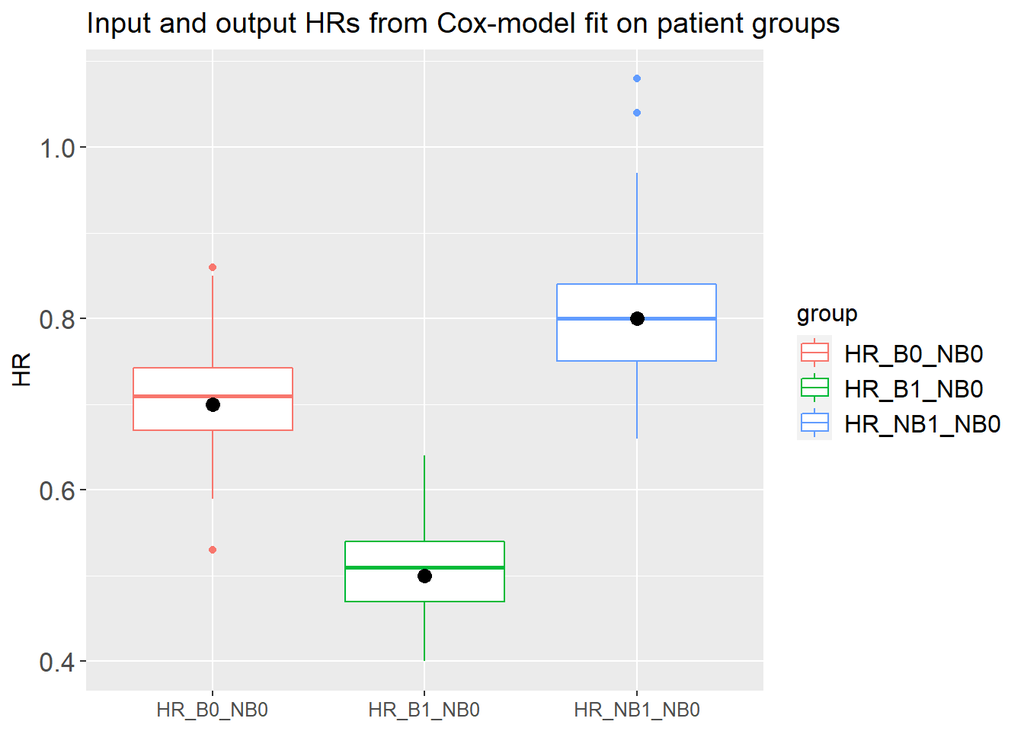

```r
n_repeats = 100
# The get_best_gep function outputs a plot, the best gep and the HRs belonging to the best gep.

gep_n_times <- get_best_gep(params, n_repeats = n_repeats, threshold = 0.03)

# Plot
gep_n_times_plot <- gep_n_times$p
gep_n_times_plot
```

```r
#save_plot(myfilename = 'cox_pt_group', myplot = cox_pt_group_p, width = 15, height = 10)
```

Check the difference between input and estimated HRs

```r
# Extract the best gep:
best_gep <- gep_n_times$best_gep
best_output_hrs <- gep_n_times$best_output_hs
best_output_hrs
```

```
##  groupB0  groupB1 groupNB1
##     0.67     0.51     0.81
```

```r
# Check difference between input and estimated HRs
diff_io_hrs <- get_diff_io_hrs(input_hrs = c(params$HR_B0_NB0, params$HR_B1_NB0,
                                             params$HR_NB1_NB0),
                               output_hrs = best_output_hrs,
                               output_format = 'table')

diff_io_hrs_kable <- kable(diff_io_hrs, format='html',
                           caption="Input and output HRs ") %>%
  kable_styling(bootstrap_options = "striped",
                full_width = F, position = "center")

diff_io_hrs_kable
```

Input and output HRs

input_hrs

output_hrs

diff

groupB0

0.7

0.67

0.03

groupB1

0.5

0.51

-0.01

groupNB1

0.8

0.81

-0.01

sum_abs

0.05

```r
# Save:
#save_kable(diff_io_hrs_kable, paste("./plots/", myfilename, ".html", sep = ""))

#write.csv(diff_io_hrs, paste('./plots/', myfilename, ".csv", sep = ""))
```

# II. Plot results of best dataset

## Set filename and title

```r
myfilename = "example"
mytitle = "Best dataset (example)"
```

## Test for proportional hazards

The plot of scaled Schoenfeld residuals should be a horizontal line. The hypothesis test identifies whether the gradient differs from zero for each variable.

```r
test_ph(best_gep)
```

```
##        chisq df     p
## group   6.35  3 0.096
## GLOBAL  6.35  3 0.096
```

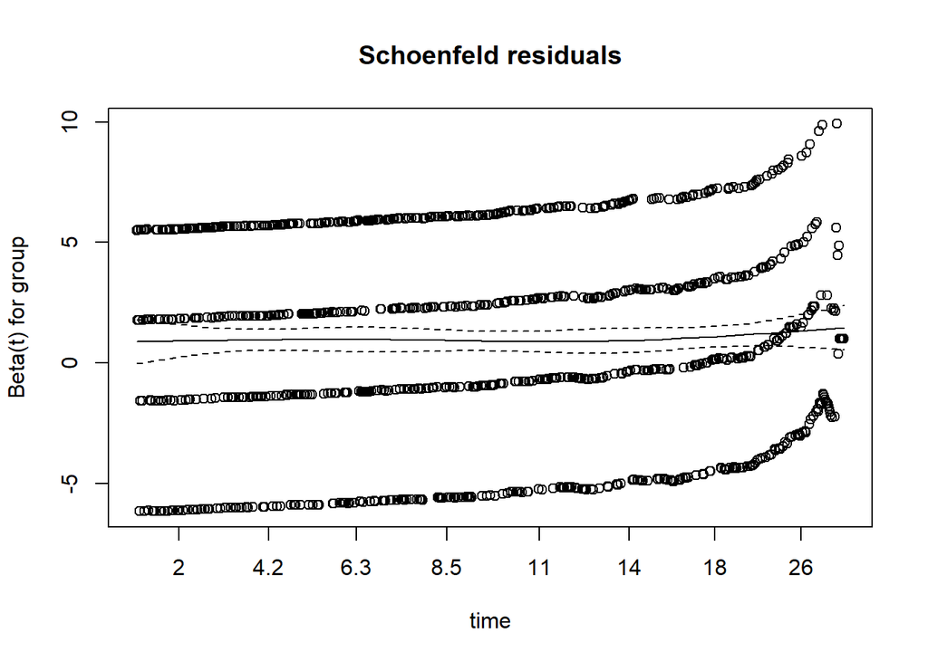

## Get hazard ratio tables

```r
# There are two output formats.

hrs <- get_hr_table(best_gep, output_format = 'per_group', mytitle)
hrs
```

Best dataset (example)

| **Characteristic** | **HR**<sup>1</sup> | **95% CI**<sup>1</sup> | **p-value** |
| --- | --- | --- | --- |
| group |  |  |  |
| NB0 | — | — |  |
| B0 | 0.67 | 0.56, 0.79 | <0.001 |
| B1 | 0.51 | 0.43, 0.61 | <0.001 |
| NB1 | 0.81 | 0.68, 0.96 | 0.017 |

<sup>1</sup> HR = Hazard Ratio, CI = Confidence Interval

```r
hrs <- get_hr_table(best_gep, output_format = 'per_benefit', mytitle)
hrs
```

Best dataset (example)

| **Characteristic** | **HR**<sup>1</sup> | **95% CI**<sup>1</sup> | **p-value** |
| --- | --- | --- | --- |
| Benefit group |  |  |  |
| group |  |  |  |
| B0 | — | — |  |
| B1 | 0.78 | 0.65, 0.93 | 0.006 |
| Non-Benefit group |  |  |  |
| group |  |  |  |
| NB0 | — | — |  |
| NB1 | 0.81 | 0.68, 0.97 | 0.021 |

<sup>1</sup> HR = Hazard Ratio, CI = Confidence Interval

```r
# Save:
#myfilename = "example2"
#save_hrs(hrs, myfilename)
```

Plot hazards

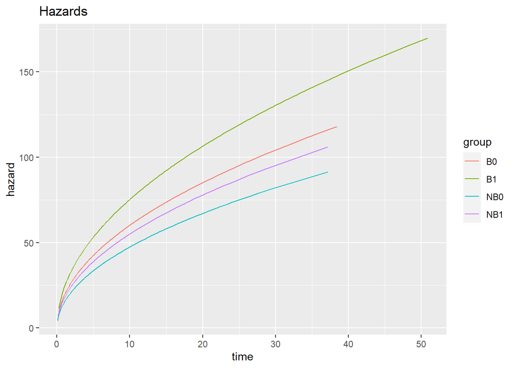

```r
plot_hazards(best_gep, shape = params$surv_d_params$shape, mytitle = "Hazards")
```

## Plot survival curves

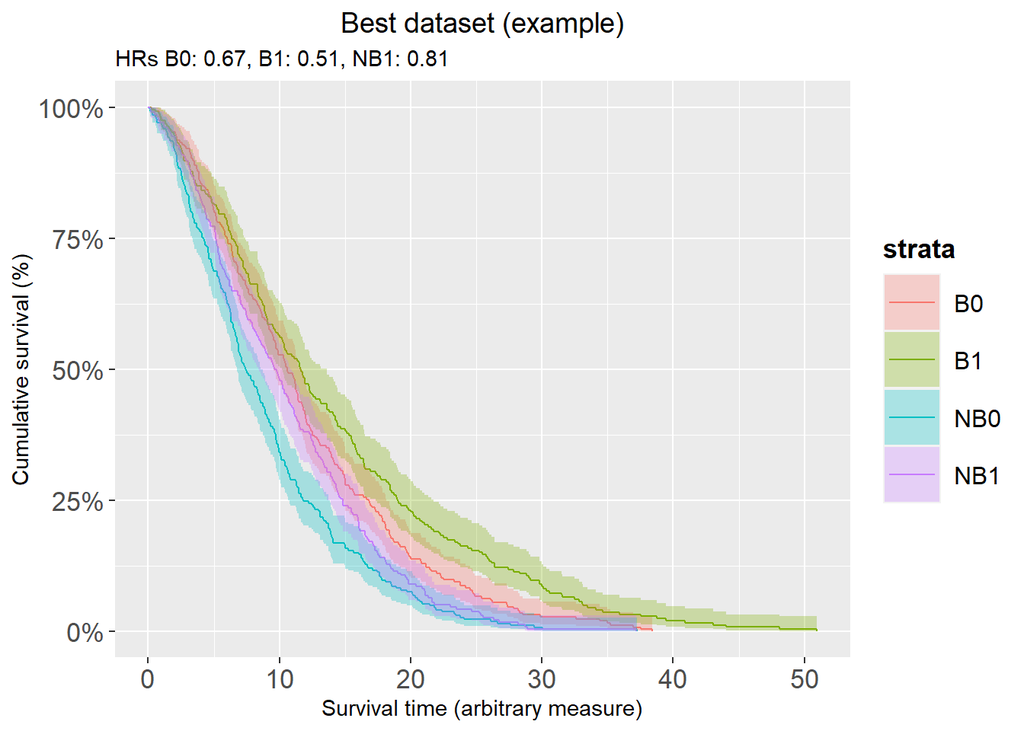

```r
survplot <- plot_km_curve(best_gep, best_output_hrs, mytitle = mytitle)
survplot
```

```r
#Save survival curves
#myfilename = "example2"
#save_plot(myfilename, myplot = survplot)
```

## Check correlation

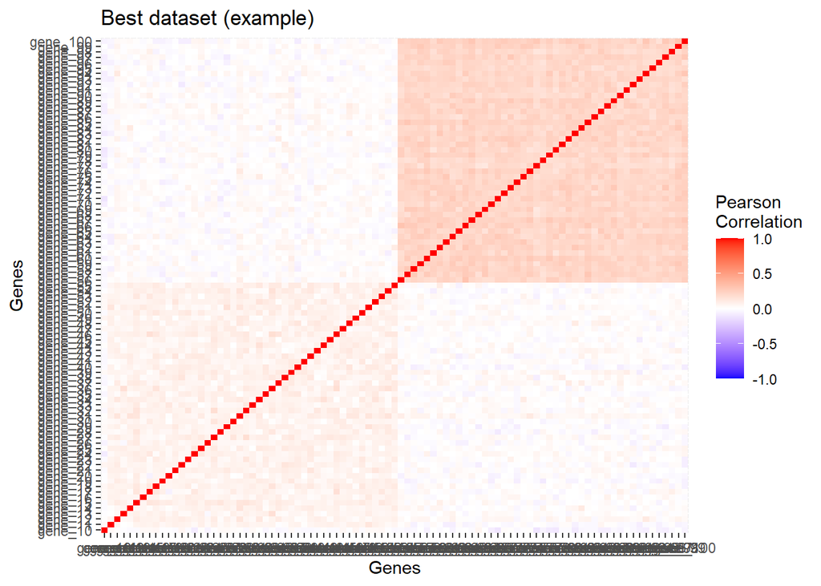

```r
# Subset the data to check correlation of parts.
marker_genes <- best_gep[,1:sum(params$marker_blocksizes)]
nonmarker_genes <- best_gep[,sum(params$marker_blocksizes):params$n_genes]
whole_gep <- best_gep[,1:params$n_genes]

check_cor(nonmarker_genes, mytitle = mytitle)
```

# III. Explore SynTruth results in scenarios

Does SynTruth construct data according to its settings?

## III/0 Make scenarios

```r
# Specify the parameters to be tuned and their values.

scenarios <- list(
  mu_diffs = c(1, 5),
  gene_effects = c('AND', 'OR', "no_pattern")
)

# Specify the rest of the params that stay constant.

params <- list(
  # parameters for marker blocks
  marker_blocksizes = c(10),
  mus_NB = c(0),
  mu_diffs = c(2),
  sds_B = c(0.4),
  sds_NB = c(0.4),
  rhos_B = c(0.8),
  rhos_NB = c(0.8),
  gene_effects = c("AND"),

  # parameters for nonmarker blocks
  mu_nonmarker = 0,
  sds_nonmarker = c(0.4),
  rhos_nonmarker = c(0.8),

  # parameters for gep
  n_pts = 1000,
  n_genes = 100,
  fraction_pts_benefit = 0.5,
  fraction_tx_1 = 0.5,
  fraction_censored = 0,
  noise = list(type = "random", mean = 0, sd = 0),

  # parameters for survival
  surv_distribution = "Weibull",
  surv_d_params = list(shape=1.5),
  scale_NB0 = 10,
  HR_B0_NB0 = 0.8,
  HR_NB1_NB0 = 0.7,
  HR_B1_NB0 = 0.5)

# The make_scenarios function outputs:
# 1. a list of parameters, in which each element has a different value of those params that are tuned. This list is the input to functions that run an analysis in different scenarios.
# 2. the names of the scenarios that are composed of the values of the params that are tuned.

scenario_params_names <- make_scenarios(scenarios, params)
scenario_params_list <- scenario_params_names$params_list
scenario_names <- scenario_params_names$sc_names
scenario_names
```

```
## [1] "1-AND"        "5-AND"        "1-OR"         "5-OR"         "1-no_pattern"
## [6] "5-no_pattern"
```

## III/A: Gene expression

### III/A/1: PCA

Is there a separation of B and NB patients?

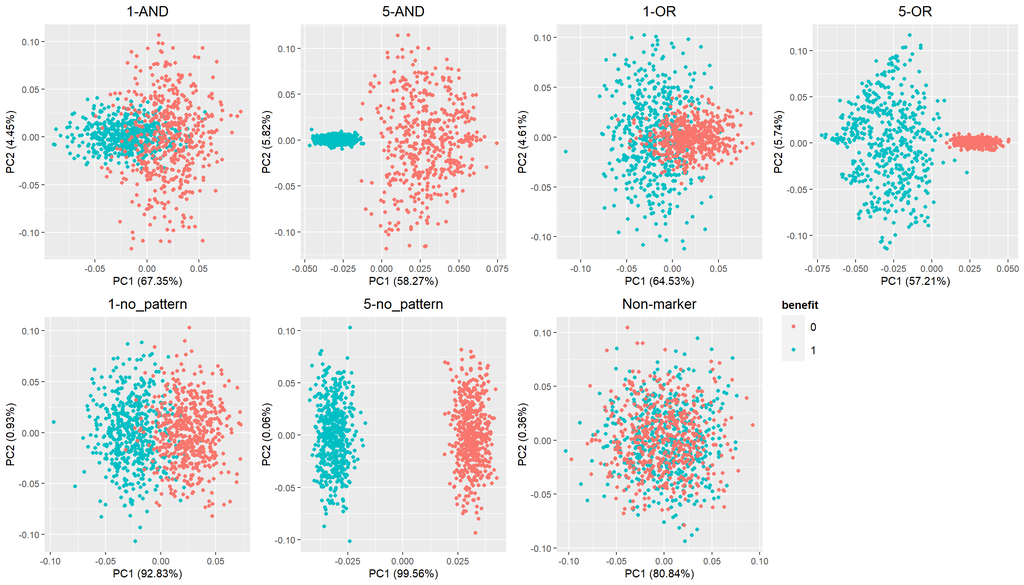

```r
library(plotly)
library(ggfortify)
library(factoextra)
library(gridExtra)

scores <- do_pca_in_scenarios(scenario_names,
                              scenarios = scenario_params_list,
                              nrow = 2)
```

```r
#save_plot(myfilename = 'scores', myplot = scores, width = 28, height = 12)
```

### III/A/2 K-means clustering, silhouette score

```r
library('factoextra')
library('cluster')
library('caret')
library('tidyverse')

km_sc_plot <- do_km_in_scenarios(scenario_names = scenario_names,
                                 scenarios = scenario_params_list,
                                 n_repeats = 100,
                                 nrows = 3)
```

```
## [1] "Number of repepats: 100"
```

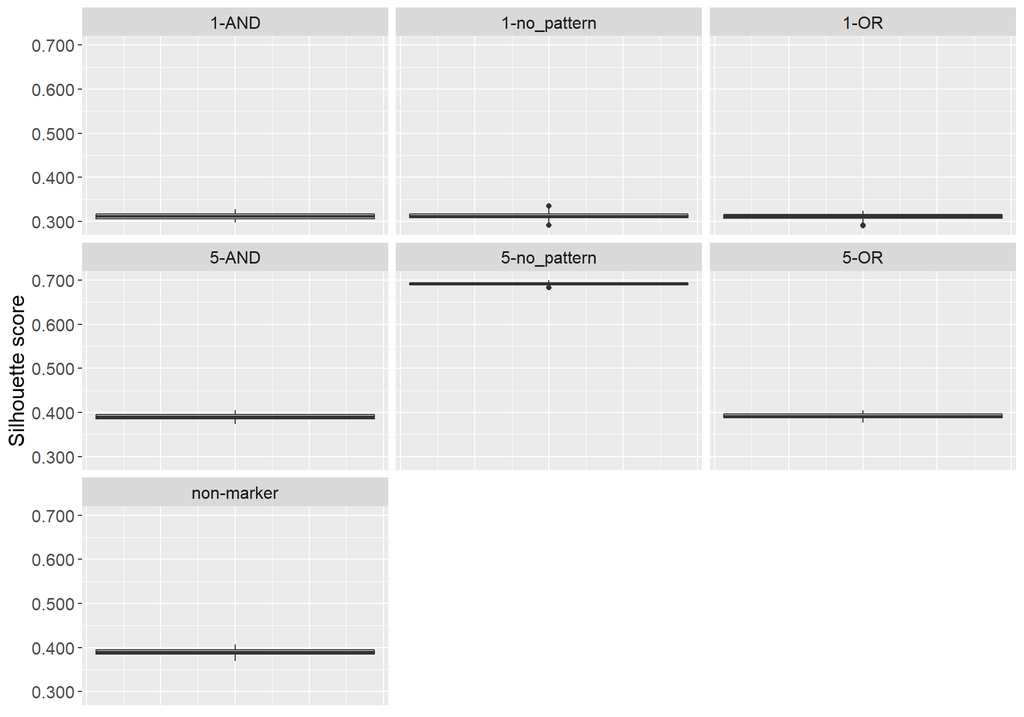

```r
km_sc_plot
```

```r
#save_plot(myfilename = 'km_sc_plot', myplot = km_sc_plot, width = 14, height = 10)
```

## III/B Can patient groups be predicted from gene expression and treatment?

This part assesses how well the four groups can be reconstructed, by feeding all data – except the true group label - into a hypothetical ‘best’ algorithm. I.e., an algorithm that knows which are the marker genes, and the logical relationship between them. This algorithm is based on the Cox-model.

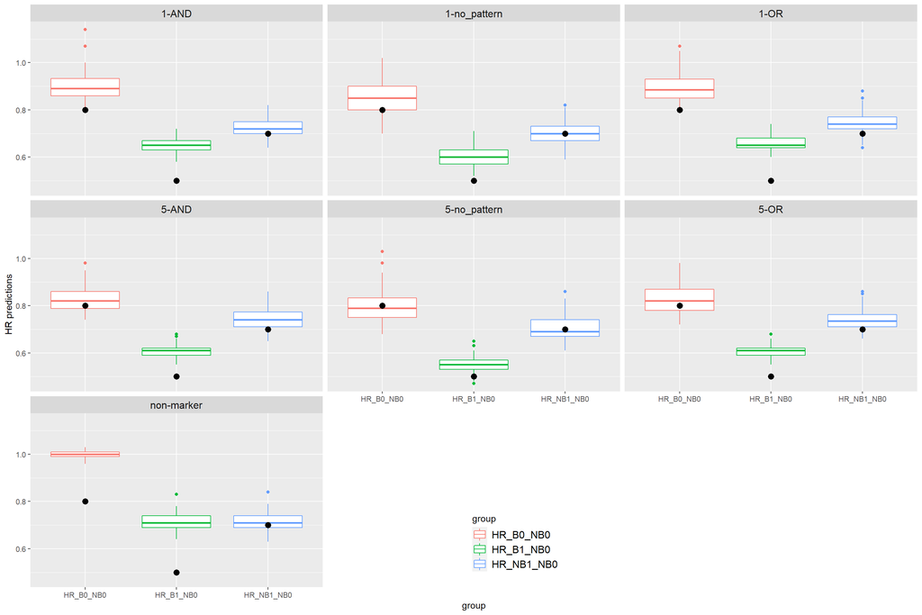

```r
cox_pred_hrs <- validate_cox_in_scenarios(scenario_names = scenario_names,
                                          scenarios = scenario_params_list,
                                          n_repeats = 100)


cox_pred_hrs
```

```r
#save_plot(myfilename = 'cox_pred_hrs', myplot = cox_pred_hrs, width = 23, height = 15)
```